# Who lives where in Mexico — a guide to the data

Diversity in a Globalized World

Published

September 9, 2026

# What this data is about

The other sessions of this course looked at things crossing borders: goods, people, money, technology. This one stays inside one country and asks a smaller question with a harder answer.

**Who lives next to whom?**

Mexico is a diverse country. About 7.4 million people speak an indigenous language and 2.6 million identify as Afro-Mexican. But a national average tells you almost nothing about anyone’s actual street. Some municipios are more than half indigenous-speaking. Over a thousand are under 1%. Diversity exists at the level of the country far more than at the level of the neighbourhood.

The same is true of money. Monterrey looks prosperous as a metropolitan area. Inside it, one municipio has a poverty rate of 5% and another has 28%.

**This folder covers all 2,469 Mexican municipios, plus 31 metropolitan areas.**

# The two files

| File | Use it for | What one row is |
| --- | --- | --- |
| `municipios.rds` | **Maps** | One municipio |
| `metros.rds` | Comparing cities | One metropolitan area |

```r
library(sf)
library(ggplot2)

municipios <- readRDS("preprocessed_data/municipios.rds")
metros     <- readRDS("preprocessed_data/metros.rds")
```

# `municipios.rds` — for maps

One row per municipio, with its shape attached. Everything is from 2020.

```r
municipios |>
  st_drop_geometry() |>
  filter(municipio %in% c("San Pedro Garza García", "El Carmen", "Oaxaca de Juárez")) |>
  select(municipio, state, pop, indigenous_pct, poverty_pct)
```

```
               municipio      state    pop indigenous_pct poverty_pct
1              El Carmen Nuevo León 104478       4.001799   28.448074
2 San Pedro Garza García Nuevo León 132169       1.908920    5.450951
3       Oaxaca de Juárez     Oaxaca 270955       7.953719   33.972684
```

| Variable | What it means |
| --- | --- |
| `id` | Five-digit INEGI municipio code |
| `municipio`, `state` | Names |
| `metro_area` | Which metropolitan area it belongs to, if any (`NA` if none) |
| `pop` | Population, 2020 |
| `indigenous_language` | People who speak an indigenous language |
| `indigenous_pct` | The same, as % of the municipio |
| `afromexican`, `afromexican_pct` | People who identify as Afro-Mexican |
| `poverty_pct` | % of residents in poverty (CONEVAL’s multidimensional measure) |
| `extreme_pct` | % in extreme poverty |
| `geometry` | The municipio’s shape — you never touch this directly |

**A map takes one line:**

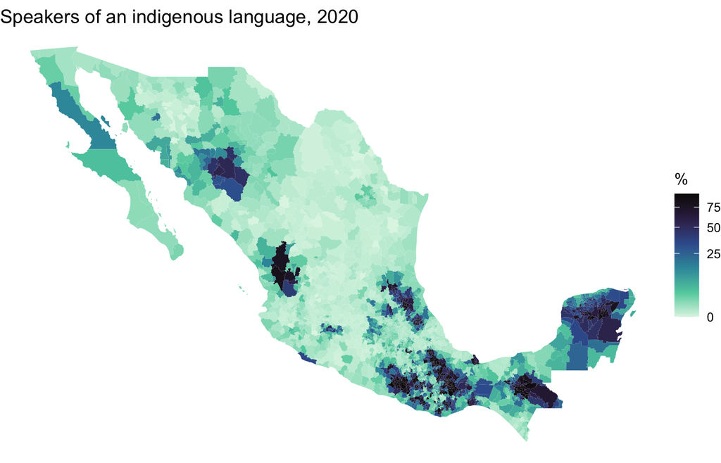

```r
ggplot(municipios) +
  geom_sf(aes(fill = indigenous_pct), color = NA) +
  scale_fill_viridis_c(option = "mako", direction = -1, trans = "sqrt",
                       na.value = "grey90", name = "%") +
  labs(title = "Speakers of an indigenous language, 2020") +
  theme_void()
```

Swap `indigenous_pct` for `afromexican_pct` or `poverty_pct` and you get a different map of the same country.

# Zooming into one city

This is the move that makes the session work. Filter to one metro area and the national map becomes a city map.

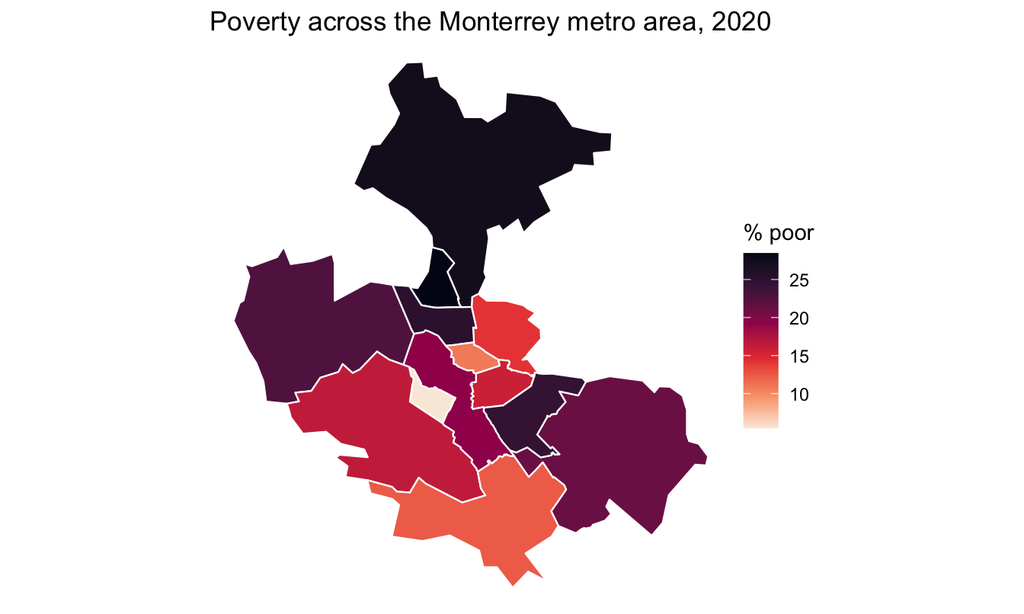

```r
mty <- municipios |> filter(metro_area == "Monterrey")

ggplot(mty) +
  geom_sf(aes(fill = poverty_pct), color = "white", linewidth = 0.4) +
  scale_fill_viridis_c(option = "rocket", direction = -1, name = "% poor") +
  labs(title = "Poverty across the Monterrey metro area, 2020") +
  theme_void()
```

Try `"Valle de México"`, `"Guadalajara"`, `"Oaxaca"` or any name in `metros$metro_area`.

# `metros.rds` — for comparing cities

One row per metropolitan area, with segregation already calculated.

```r
metros |> select(metro_area, n_municipios, dissim_poverty, poverty_gap) |> head(5)
```

```
# A tibble: 5 × 4
  metro_area      n_municipios dissim_poverty poverty_gap
  <chr>                  <int>          <dbl>       <dbl>
1 Valle de México           76          0.195        67.7
2 Guadalajara                8          0.106        15.2
3 Monterrey                 13          0.138        23.0
4 Puebla-Tlaxcala           39          0.220        54.5
5 Toluca                    15          0.129        32.0
```

| Variable | What it means |
| --- | --- |
| `metro_area` | Name |
| `n_municipios`, `pop` | How many municipios, and total population |
| `dissim_indigenous` | Index of dissimilarity for indigenous-language speakers |
| `dissim_poverty` | Index of dissimilarity for people in poverty |
| `poverty_lowest` / `poverty_highest` | Poverty rate in its best-off and worst-off municipio |
| `poverty_gap` | The difference between those two |

## What the index of dissimilarity means

It answers one question: **what share of one group would have to move for the two groups to be spread evenly across the city?**

`0` means every municipio looks like the metro as a whole. `1` means the two groups share no municipio at all. Monterrey scores 0.26 for indigenous speakers and 0.14 for poverty.

# The most important limitation

**These are municipios, and municipios are big.** Monterrey municipio alone holds over a million people. Averaging across a unit that large smooths away most of the sorting that actually happens, which occurs street by street.

So every segregation number in this folder is a **floor, not a ceiling**. The real figures are higher. If you report one, say which unit you used and note that a smaller unit would give a bigger number. That sentence is the difference between a good report and a misleading one.

# Other things worth knowing

**Three municipios have no poverty figure**, out of 2,469. They come out grey on a map, which is honest — leave them grey rather than setting them to zero.

**`indigenous_language` counts speakers, not identity.** Someone can identify as indigenous without speaking an indigenous language, and the census asks both questions separately. This variable is the language one, so it undercounts.

**Poverty here is CONEVAL’s multidimensional measure**, not an income line. It combines income with access to education, health services, housing and food. That is why municipal rates look high: the population-weighted national figure is 44%.

**Both main variables are lopsided.** Indigenous share runs from 0 to 98%, and most municipios are near zero. `trans = "sqrt"` inside the fill scale keeps the map from being one flat colour.

# Questions you could ask

- Which metro area is most unequal internally, and is it the one you expected?
- Does the map of indigenous Mexico line up with the map of poor Mexico? Where does it *not*?
- Pick your home city. Where does it sit among the 31 metros?
- Are municipios with more Afro-Mexican residents poorer, richer, or neither?
- Compare `dissim_indigenous` with `dissim_poverty`. Do the same cities top both lists? What would it mean if they did not?
- Find a municipio that breaks the national pattern, and try to work out why.

# Where the data comes from

Population, indigenous language and Afro-Mexican counts: INEGI, *Censo de Población y Vivienda 2020*, via the `mxmaps` R package.

Poverty: CONEVAL, *Medición de la pobreza a nivel municipio 2020*.

Municipio boundaries: `mxmaps`. We joined the three sources on the five-digit INEGI municipio code, computed the percentage variables and the dissimilarity indices, and attached the shapes.